# Group5_RMarkdown

Arnav Pandey, Themesha Parker, Michelle Bautista Canuto, Dhanush Devanand

2026-04-26

# Section 1: Create, Save, and Knit Your First R Markdown File

Author: Jaslyn Davenport (jcdavenport@uncg.edu)

Objective: Learn how to create and generate a basic R Markdown document.

…………………….

## 1.1 How I Created a New R Markdown File

…………………….

To begin, open RStudio and create a new R Markdown file.  
Go to **File > New File > R Markdown**.

QUESTION: What do you think happens when the new file is opened?  
ANSWER: It likely makes a new R Markdown file.

…………………….

## 1.2 Install and Load Packages

…………………….

Before knitting your file, make sure the required packages are installed and loaded.

TASK: Run the following in the Console:

install.packages(“rmarkdown”) install.packages(“knitr”) library(rmarkdown) library(knitr) install.packages(“tinytex”) tinytex::install_tinytex()

QUESTION: Why are these packages needed? ANSWER: Probably because they’re used to make the file work.

……………………. ## 1.3 Modify the YAML Header

At the top of the file, you will see the YAML header between two sets of — This section controls the document settings.

TASK: Change the YAML header so that it includes: a new title your name as the author the date PDF output

Example: title: “My First R Markdown File” author: “Jaslyn Davenport” date: “April 2026” output: pdf_document

QUESTION: What is the purpose of the YAML header? ANSWER: It basically dictates basic info about the document.

……………………. ##1.4 Save and Knit file

After editing the file, save it as an .Rmd file. Then click the Knit button at the top of RStudio.

If you get an error message about LaTeX or TinyTeX, install TinyTeX by running: install.packages(“tinytex”) tinytex::install_tinytex() Then click Knit again.

QUESTION: What happens when you click Knit? ANSWER: It basically made a pdf file and let me view it.

QUESTION: What type of file is created? ANSWER: Pdf

……………………. ##1.5 Final observation After knitting, compare the .Rmd file to the final PDF.

QUESTION: How is the output file different from the source file? ANSWER: The output file is a pdf that can’t be turned back into a rmd file. The source file can on the other hand be ourputted as a pdf.

# Section 2: Formatting Text Using RMarkdown Syntax

Author: Arnav Pandey (a_pandey2@uncg.edu)

Objective: learn how to format the appearance of your document in your chosen output format.

…………………….

## 2.1. Headings

…………………….

TASK: Read the question below, click **Knit** to render the document and return here to answer the question.

QUESTION: What difference do you notice about the above line that starts with `# Section 2: Formatting a Report Using RMarkdown Syntax` compared to the line `Objective: learn to format how your document appears in the output of your choice`?  
ANSWER: They’re both bold, but the first one is also slightly bigger..?

Placing a hashtag (#) at the beginning of a line turns it into a heading. RMarkdown supports six levels of headings.

TASK: Click Knit to observe how different heading levels below appear in the rendered output.

```
# Line 1: This is an example to show different levels of headings in RMarkdown.
## Line 2: Line 1: This is an example to show different levels of headings in RMarkdown.
### Line 3: This is an example to show different levels of headings in RMarkdown.
#### Line 4: This is an example to show different levels of headings in RMarkdown.
##### Line 5: This is an example to show different levels of headings in RMarkdown.
###### Line 6: This is an example to show different levels of headings in RMarkdown.
```

QUESTION: What happens to the size of text when you increase the number of hashtags (#)?  
ANSWER:

The first line is the biggest and they get progressively smaller the lower you go.

In the example above, the higher the number of hashtags, the lower the heading level (smaller font).

QUESTION: How many hashtags would you use if you wanted highest level heading (largest font)?  
ANSWER:

Just one

QUESTION: In the rendered output, do Line 5 and Line 6 from above example appear in the same line?  
ANSWER:

Yes

TASK: Go to the metadata for this assignment and change the output from `pdf_document` to `html_document`.

QUESTION: Did your Line 5 and Line 6 appear in different lines?  
ANSWER:

Yes

Sometimes the way the program renders output differs between formats. You can leave two spaces at the end of the line for a line break.

TASK: Change the output back to `pdf_document`.

TASK: **Go back**to all the above example lines “Line 1” thru “Line 6” within single set of three backticks ```. Go back above and do as below:

```
# Line 1: This is an example to show different levels of headings in RMarkdown.
## Line 2: Line 1: This is an example to show different levels of headings in RMarkdown.
### Line 3: This is an example to show different levels of headings in RMarkdown.
#### Line 4: This is an example to show different levels of headings in RMarkdown.
##### Line 5: This is an example to show different levels of headings in RMarkdown.
###### Line 6: This is an example to show different levels of headings in RMarkdown.
```

…………………….

## 2.2 Italics

…………………….  
You may sometimes want to italicize text. RMarkdown allows you to do this easily. To make your text italics, you can enclose it within single asterisk `*[text]*`.

*Line 1: This is an example to show how to make text italics.*

TASK: Rewrite Line 1 below and only italicize the word “italics.” Leave two spaces at the end of sentence for a line break.  
ANSWER:

Line 1: This is an example to show how to make text *italics*.

You may be wondering if there is another way to make the text italics, and in fact, there is. You can also enclose your text within single underscore `_[text]_`.

TASK: In the paragraph below, make “Arnav,” “Biological Data Wrangling and Visualization” and “RMarkdown” italics in the following paragraph using both the methods (asterisks and underscore) mentioned above at least once.

My name is *Arnav* Pandey. I am currently enrolled in *Biological Data Wrangling and Visualization* (BIO 457/657).This is a TASK: to use *RMarkdown* to make a text output italics.

…………………….

## 2.3 Bold

…………………….  
Sometimes you may want to bold your text to emphasize its importance. RMarkdown supports that as well.

TASK: Read the question below, click Knit, and return to answer the question below.

QUESTION: Which of the following lines gives you bold text?  
Line 1. This is an example to show how to make text bold.  
**Line 2: This is an example to show how to make text bold.**  
ANSWER: It’s the second line.

You can use two asterisks before and after the text to make it bold (`**[text]**`).  
There is also another way to make a text bold by enclosing your text within two underscores(`__[text]__`).

Don’t believe me? Knit to see if the line below is bold.

**Line 3: This is an example to show how to make text bold.**

Like you practiced with italics, you can make any word or phrase within a sentence bold. See example of it below when you hit Knit.  
Line 5: This is an example to show how to make text **bold**.  
Line 4: This is an **example** to show how to make text bold.

TASK: In the paragraph below, make “Arnav,” “Biological Data Wrangling and Visualization” and “RMarkdown” bold in the following paragraph using both the methods (asterisks and underscores) mentioned above at least once.  
My name is **Arnav** Pandey. I am currently enrolled in **Biological Data Wrangling and Visualization** (BIO 457/657). This is a TASK: to use **RMarkdown** to make a text output bold.

…………………….

## 2.4 Bold and Italics

…………………….

Is there a way to make a text both bold and italics at the same time? Indeed, there is! You can enclose your text within three asterisks (`***[text]***`). or underscores (`___[text]___`).

TASK: In the paragraph below, make “Arnav,” “Biological Data Wrangling and Visualization” and “RMarkdown” bold italics using both the methods mentioned above at least once.  
My name is *Arnav* Pandey. I am currently enrolled in *Biological Data Wrangling and Visualization* (BIO 457/657). This is a TASK: to use *RMarkdown* to make a text output bold.

In sections 2.2, 2.3, and 2.4, you learnt how to make text italics, bold, or bold+italics by enclosing the text within one, two, and three asterisks or underscores, respectively. You might be tempted to start enclosing a text by underscore and end it using asterisk. For example:

*italics_  
__bold**  
***bold italics___

Above lines will not give your desired output, so you will have to be consistent with how you enclose your texts. Use the same symbols at both ends! `[R Markdown documentation](https://rmarkdown.rstudio.com)`

…………………….

## 2.5 Bulleted list

…………………….

In RMarkdown, you can list your items in the RMarkdown as an unordered (bulleted) list.

To do that, you can follow these steps. Step 1: leave an empty line before list. Step 2: Use ‘+’, ‘-’, or ’*’ followed by single space before you write your list item.  
Step 3: To add another item, leave two spaces at the end of the previous item and go to a new line below and repeat Step 2.

TASK: Knit to see how the items below appear in a list in the output.

- Apple
- Banana
- Raspberry

You can also nest subitems within an item. If you want a nested list as such, just indent the subitem that you want within an item with two spaces. Below is an example of it.

TASK: Hit Knit to look at the output of the lines below:

- Apple
- Banana
- Berries
  - Blueberries
  - Strawberries
  - Raspberries
  - Blackberries
  - Cranberries
- Papaya

TASK: Copy the above list below, add an item “Melon” and nest different types of melons as its subitems. Hit Knit to see your output.  
- Apple - Banana - Berries - Blueberries - Strawberries - Raspberries - Blackberries - Cranberries - Papaya - Melon - Watermelon - Musk Melon - Honeydew - Cantaloupe

…………………….

## 2.6 Numbered List

…………………….

Getting a numbered list is even easier compared to unordered or bulleted list. To generate a numbered list, you can follow these steps. Step 1: Leave an empty line before list. Step 2: Use uppercase/lowercase English alphabets, Arabic numerals, uppercase or lowercase roman numerals followed by space before you write your list item. Be consistent how you want to list. Step 3: To add another item, leave two spaces at the end of the previous item and go to a new line below and repeat Step 2.

I. Apple  
II. Banana  
III. Raspberry

You can also nest subitems within an item. If you want a nested list as such, just indent the subitem that you want within an item with three spaces. You can use different order format for your subitems than your primary item as well. Below is an example of it. **Please be careful with spaces!**

1. Apple
2. Banana
3. Berries
   1. Blueberries
   2. Strawberries
   3. Raspberries
   4. Blackberries
   5. Cranberries
4. Papaya

Note: If you want to use Roman Numerals, you may have to leave an empty line between items on list.

# Section 3: Inserting Code Chunks and Running Basic R Code

Author: Michelle Bautista Canuto (m_bautistac@uncg.edu) We can insert a code chunk by clicking on the green-button with a “c” on the inside and a “+” on the upper left. Click “R”. We can insert functions within the chunk of code. We will see this next.

QUESTION: What is a code chunk? (hint look back at the slides in Canvas) ANSWER: A block of R code within a markdown document.

TASK: Practice inserting a code chunk. Run a simple calculation such as “2+2” below {r}. Run this code by clicking on the green side-triangle button:

```r
2+2
```

```
## [1] 4
```

Next, let’s assign variables. Run the following variables:

```r
x<-10
y<-5
```

To view the contents of the variable x, just type ‘x’ and run

```r
x
```

```
## [1] 10
```

TASK: Write a chunk of code mulitpliying the variables x and y.

```r
x*y
```

```
## [1] 50
```

QUESTION: What was the result? ANSWER: 50

We will analyze the built-in ‘mtcars’ dataset. Run the following chunk of code.

```r
head(mtcars)
```

```
##                    mpg cyl disp  hp drat    wt  qsec vs am gear carb
## Mazda RX4         21.0   6  160 110 3.90 2.620 16.46  0  1    4    4
## Mazda RX4 Wag     21.0   6  160 110 3.90 2.875 17.02  0  1    4    4
## Datsun 710        22.8   4  108  93 3.85 2.320 18.61  1  1    4    1
## Hornet 4 Drive    21.4   6  258 110 3.08 3.215 19.44  1  0    3    1
## Hornet Sportabout 18.7   8  360 175 3.15 3.440 17.02  0  0    3    2
## Valiant           18.1   6  225 105 2.76 3.460 20.22  1  0    3    1
```

QUESTION: What do you think the head() function does? ANSWER: Displays the first few rows of a dataset.

To display the summary statistics for the dataset use the summary() function. Run the following chunk of code.

```r
summary(mtcars)
```

```
##       mpg             cyl             disp             hp
##  Min.   :10.40   Min.   :4.000   Min.   : 71.1   Min.   : 52.0
##  1st Qu.:15.43   1st Qu.:4.000   1st Qu.:120.8   1st Qu.: 96.5
##  Median :19.20   Median :6.000   Median :196.3   Median :123.0
##  Mean   :20.09   Mean   :6.188   Mean   :230.7   Mean   :146.7
##  3rd Qu.:22.80   3rd Qu.:8.000   3rd Qu.:326.0   3rd Qu.:180.0
##  Max.   :33.90   Max.   :8.000   Max.   :472.0   Max.   :335.0
##       drat             wt             qsec             vs
##  Min.   :2.760   Min.   :1.513   Min.   :14.50   Min.   :0.0000
##  1st Qu.:3.080   1st Qu.:2.581   1st Qu.:16.89   1st Qu.:0.0000
##  Median :3.695   Median :3.325   Median :17.71   Median :0.0000
##  Mean   :3.597   Mean   :3.217   Mean   :17.85   Mean   :0.4375
##  3rd Qu.:3.920   3rd Qu.:3.610   3rd Qu.:18.90   3rd Qu.:1.0000
##  Max.   :4.930   Max.   :5.424   Max.   :22.90   Max.   :1.0000
##        am              gear            carb
##  Min.   :0.0000   Min.   :3.000   Min.   :1.000
##  1st Qu.:0.0000   1st Qu.:3.000   1st Qu.:2.000
##  Median :0.0000   Median :4.000   Median :2.000
##  Mean   :0.4062   Mean   :3.688   Mean   :2.812
##  3rd Qu.:1.0000   3rd Qu.:4.000   3rd Qu.:4.000
##  Max.   :1.0000   Max.   :5.000   Max.   :8.000
```

Within a new chunk of code, we will code to import the entire mtcars dataset. Run the following code by clicking on the green side-triangle button for “Run Current Chunk”

```r
data(mtcars)
```

QUESTION: After running the previous code, view the dataframe of mtcars. How many variables are in the mtcars dataset? ANSWER: 11

Or you can view the dataset in the console by typing “mtcars” and click ‘Run Selected Lines’. mtcars

To find the number of rows in the dataset, we can use the nrow() function within a new chunk of code. Run the following code.

```r
nrow(mtcars)
```

```
## [1] 32
```

TASK: Write a code to find the number of columns in the ‘mtcars’ dataset using the ncol() function. Remember to use a new chunk of code.

```r
ncol(mtcars)
```

```
## [1] 11
```

QUESTION: What is the result showing in your script? ANSWER: 11

The ‘disp’ column in the dataset stands for engine displacement. Engine displacement tells you how big the engine is in cubic inches. The ‘mpg’ column stands for fuel efficiency in miles per gallon. Lets plot a graph showing fuel efficiency over displacement for each car. Run the following code. plot(mtcars$disp, mtcars$mpg)

QUESTION: What trend is the plot showing? ANSWER: It shows a negative correlation between engine displacement and mpg.

We can also use ggplot to run this within our chunk of code. This permits our plot to be displayed in the final report once “knit”.

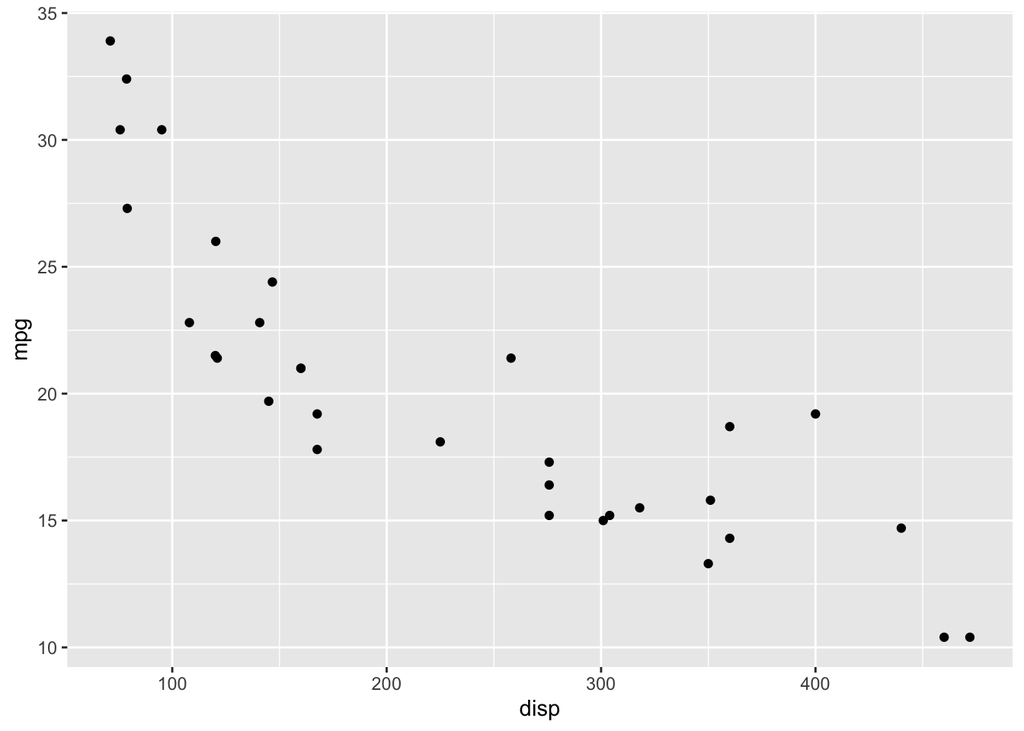

Let’s change the labels of the x-axis to ‘Engine Size (cubic inches)’ Let’s change the y-axis to ‘Miles Per Gallon’ Let’s add a title called “Fuel Efficiency vs Engine Size”.

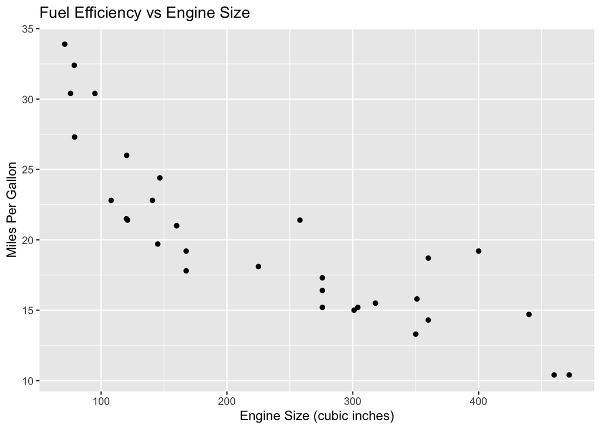

We could add a legend to show which car each point corresponds to. But first, we should add a column displaying the car names using dplyr.

```r
library(dplyr)
mtcars<-mtcars %>%
  mutate(car_name=rownames(mtcars))
```

Lets’bold’ the title Let’s add a legend to differentiate each point.

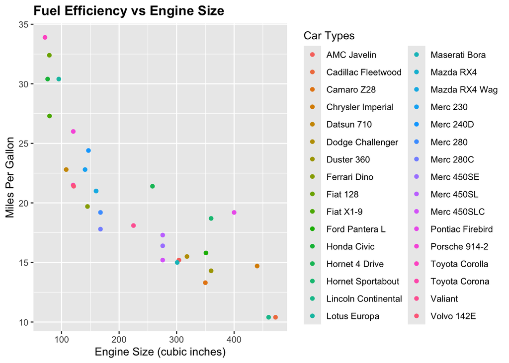

Lets organize the fuel efficiency from highest to lowest. Run the following.

```r
mtcars %>%
  select(mpg,disp) %>%
  arrange(desc(mpg))
```

```
##                      mpg  disp
## Toyota Corolla      33.9  71.1
## Fiat 128            32.4  78.7
## Honda Civic         30.4  75.7
## Lotus Europa        30.4  95.1
## Fiat X1-9           27.3  79.0
## Porsche 914-2       26.0 120.3
## Merc 240D           24.4 146.7
## Datsun 710          22.8 108.0
## Merc 230            22.8 140.8
## Toyota Corona       21.5 120.1
## Hornet 4 Drive      21.4 258.0
## Volvo 142E          21.4 121.0
## Mazda RX4           21.0 160.0
## Mazda RX4 Wag       21.0 160.0
## Ferrari Dino        19.7 145.0
## Merc 280            19.2 167.6
## Pontiac Firebird    19.2 400.0
## Hornet Sportabout   18.7 360.0
## Valiant             18.1 225.0
## Merc 280C           17.8 167.6
## Merc 450SL          17.3 275.8
## Merc 450SE          16.4 275.8
## Ford Pantera L      15.8 351.0
## Dodge Challenger    15.5 318.0
## Merc 450SLC         15.2 275.8
## AMC Javelin         15.2 304.0
## Maserati Bora       15.0 301.0
## Chrysler Imperial   14.7 440.0
## Duster 360          14.3 360.0
## Camaro Z28          13.3 350.0
## Cadillac Fleetwood  10.4 472.0
## Lincoln Continental 10.4 460.0
```

QUESTION: Which car has the highest fuel efficiency? ANSWER: Toyota Corolla

QUESTION: What is the size of it’s engine? ANSWER: 71.1 cubic inches

TASK: Use code to create a plot comparing disp vs hp from the ‘mtcars’ dataset. With the following:  
Use the ‘disp’ data for the x-axis and labeled ‘Engine Size (cubic inches)’ Use the ‘hp’ data for the y-axis and labeled ‘Horsepower (HP)’ Add an appropriate title for the plot with a ‘bold’ font Add a legend colored by ‘car_name’ and labeled “Car Types”

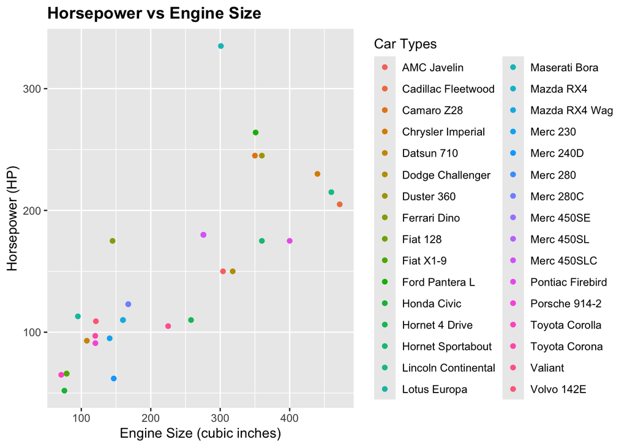

Lets organize the horsepower from highest to lowest. Run the following.

```r
mtcars %>%
  select(hp,disp) %>%
  arrange(desc(hp))
```

```
##                      hp  disp
## Maserati Bora       335 301.0
## Ford Pantera L      264 351.0
## Duster 360          245 360.0
## Camaro Z28          245 350.0
## Chrysler Imperial   230 440.0
## Lincoln Continental 215 460.0
## Cadillac Fleetwood  205 472.0
## Merc 450SE          180 275.8
## Merc 450SL          180 275.8
## Merc 450SLC         180 275.8
## Hornet Sportabout   175 360.0
## Pontiac Firebird    175 400.0
## Ferrari Dino        175 145.0
## Dodge Challenger    150 318.0
## AMC Javelin         150 304.0
## Merc 280            123 167.6
## Merc 280C           123 167.6
## Lotus Europa        113  95.1
## Mazda RX4           110 160.0
## Mazda RX4 Wag       110 160.0
## Hornet 4 Drive      110 258.0
## Volvo 142E          109 121.0
## Valiant             105 225.0
## Toyota Corona        97 120.1
## Merc 230             95 140.8
## Datsun 710           93 108.0
## Porsche 914-2        91 120.3
## Fiat 128             66  78.7
## Fiat X1-9            66  79.0
## Toyota Corolla       65  71.1
## Merc 240D            62 146.7
## Honda Civic          52  75.7
```

QUESTION: What trend is the plot showing between engine size and horsepower? ANSWER: There’s a positive correlation between engine size and horsepower.

QUESTION: Which cars have the highest and lowest hp? ANSWER: Maserati Bora has the highest hp and Honda Civic has the lowest hp.

Don’t forget to save and commit your changes.

[output not shown]

## Part A: Create a Scatterplot

The variables wt and mpg in the mtcars data set can help us explore the relationship between car weight and fuel efficiency.

### TASK:

Create a scatter plot with wt on the x-axis and mpg on the y-axis.

**Hint:** use the plot() function

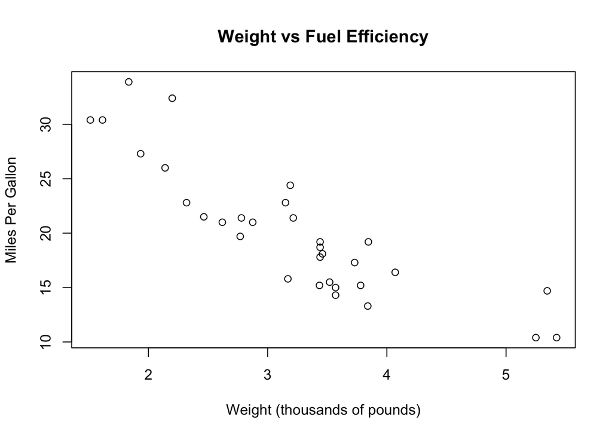

```r
# Write your code below this line

plot(x = mtcars$wt, y = mtcars$mpg, xlab = "Weight (thousands of pounds)", ylab = "Miles Per Gallon", main = "Weight vs Fuel Efficiency")
```

### TASK:

Modify your scatterplot so that it includes: a title, an x-axis label, a y-axis label, a point color of your choice

**Hint:** Think back to previous assignments(main=, xlab= ,ylab=, and col=)

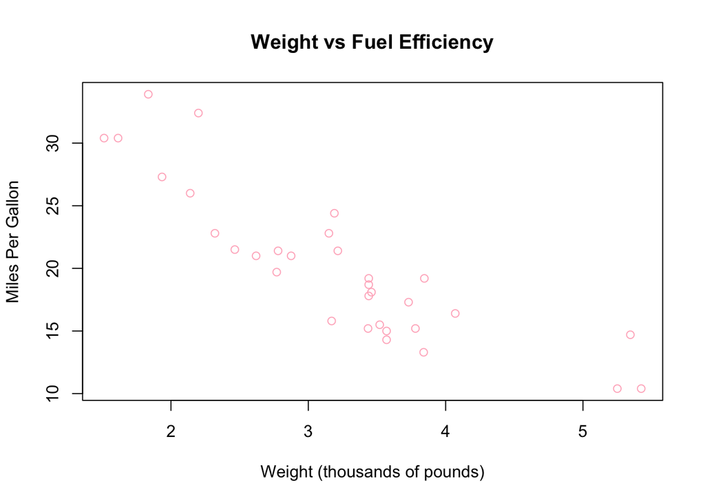

```r
# Write your updated scatterplot code below this line

plot(x = mtcars$wt, y = mtcars$mpg, xlab = "Weight (thousands of pounds)", ylab = "Miles Per Gallon", main = "Weight vs Fuel Efficiency", col = "pink1")
```

QUESTION: What does each point in this scatterplot represent? ANSWER: It represents a car.

QUESTION: What relationship do you observe between weight and mpg? ANSWER: There’s a negative correlation.

QUESTION: Does the graph suggest a positive relationship, a negative relationship, or no relationship? Explain your answer. ANSWER: It represents a negative relationship since higher weight corresponds to lower fuel efficiency overall.

## Part B: Create a Boxplot

The variable cyl shows the number of cylinders in each car. A boxplot can help compare fuel efficiency across cylinder groups.

### TASK:

Create a boxplot of mpg by cyl using the boxplot function

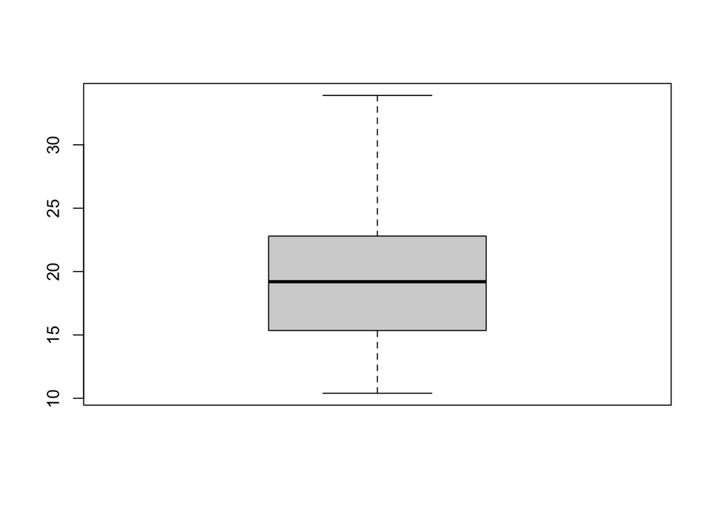

```r
# Write your code below this line
boxplot(y = mtcars$cyl, x = mtcars$mpg)
```

### TASK:

Modify your boxplot so that it includes: a title, an x-axis label, a y-axis label, and a fill color of your choice

[figure not shown]

```r
# Write your updated boxplot code below this line
boxplot(y = mtcars$cyl, x = mtcars$mpg, ylab = "Cylinder Group", xlab = "Miles Per Gallon", main = "Cylinder Group vs Fuel Efficiency", col = "pink")
```

QUESTION: What does each box in this plot represent? ANSWER: It represents the distribution..?

## Part C: Create a Summary Table

You will now create a table showing the average miles per gallon for each cylinder group.

### TASK:

Use dplyr to calculate the average mpg for each value of cyl. Rename the data avg_mpg_by_cyl

**Hint:** you need to group the data by cyl then summarize the mean of mpg.

Use the space below to write your code:

```r
# Write your code below this line
library(dplyr)
avg_mpg_by_cyl <- mtcars %>%
  group_by(cyl) %>%
  summarise(mean_mpg = mean(mpg))
```

### TASK:

Display your results as a clean table.

Use the space below to write your code:

```r
# Write your code below this line
knitr::kable(avg_mpg_by_cyl)
```

| cyl | mean_mpg |
| --- | --- |
| 4 | 26.66364 |
| 6 | 19.74286 |
| 8 | 15.10000 |

QUESTION: What does this table show? ANSWER: It shows the average fuel efficiency for each cylinder rating.

QUESTION: Which cylinder group has the highest average mpg? ANSWER: 4

QUESTION: Which cylinder group has the lowest average mpg? ANSWER: 8

## Part D: Compare the Visuals

Now that you have created both graphs and the table, compare the information they provide.

QUESTION: How does the scatterplot help you understand the relationship between weight and fuel efficiency? ANSWER: It provides a very easy way of comparing the data accross several datapoints.

QUESTION: How does the boxplot help you compare different groups of cars? ANSWER: It allows us to see overall trends in the distribution of the data.

## Part E: Now you try

1. Use a different variable from mtcars to make an additional scatter plot.
2. Change the color of your scatterplot.

Write your code below:

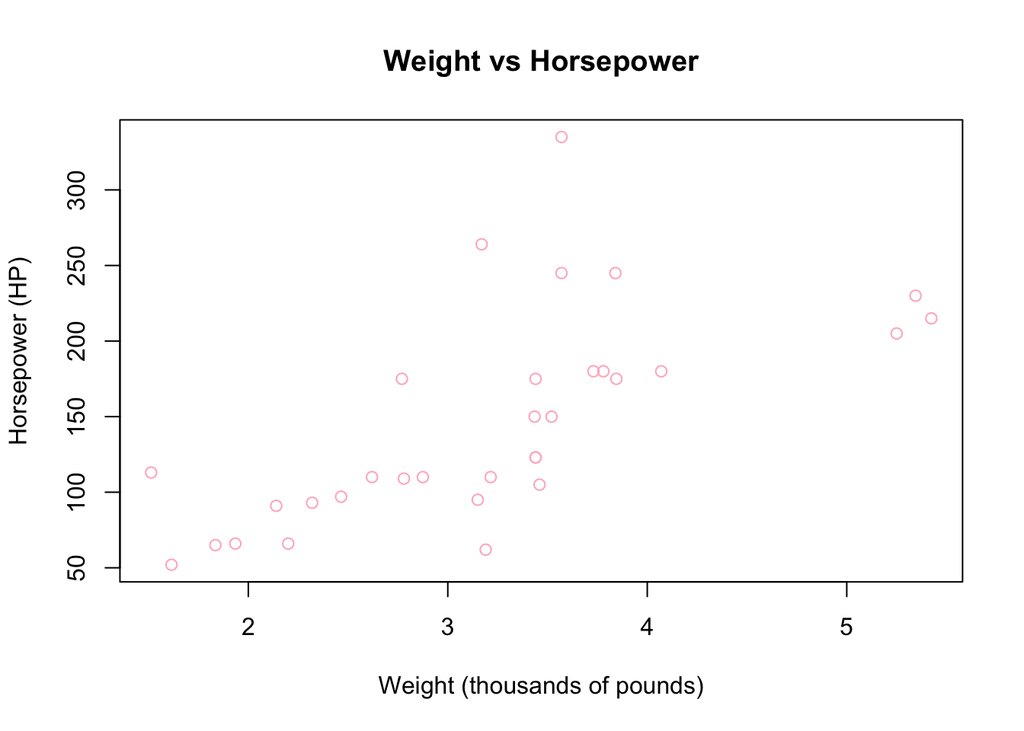

```r
plot(x = mtcars$wt, y = mtcars$hp, xlab = "Weight (thousands of pounds)", ylab = "Horsepower (HP)", main = "Weight vs Horsepower", col = "pink1")
```

QUESTION: What did you change, and how did it affect the output? ANSWER: This graph shows the correlation between weight and horsepower.

# ———————————————————-

# Section 5: Improve and Finalize Your R Markdown Report

**Objective:** Learn how to make your report more polished, readable, and professional. In this section, we will take everything we have learned and improve the overall quality of our R Markdown report so it is easier to read and more useful.

Author: Dhanush Devanand (s_devanand@uncg.edu)

## Step 1: Understanding Inline R Code

So far, we have been writing code in chunks. However, sometimes we want to include results directly inside our text. **Inline R code** allows us to insert calculations into sentences without a separate code chunk.

### TASK:

Copy and paste the following lines directly into your R Markdown document, **outside** of any code chunk, and then Knit:

```
The mtcars dataset has 32 rows and 12 columns.
The average miles per gallon (mpg) is 20.09.
```

### Check

Did the numbers appear automatically in your rendered sentence? Yes

QUESTION: What is inline R code, and how is it different from a regular code chunk? ANSWER: It basically uses code to embed values into sections of regular text.

QUESTION: Why is inline R code useful when working with a dataset that might be updated or changed over time? ANSWER: You can just have it update automatically when the variable/observation is edited rather than manually changing the value at each instance.

### TASK:

Now try writing your own inline R code sentence. Using the mtcars dataset, write a sentence that includes the maximum horsepower value using inline R code. The function `max()` will be helpful here.

The mtcars dataset has 335 as the maximum horsepower.

### Why This Matters

Inline R code makes your report dynamic. If the dataset changes, your results will automatically update without you needing to rewrite anything. This is especially important in professional or scientific reports where accuracy matters.

## Step 2: Improving Readability by Hiding Code

Sometimes, showing all code can make a report look cluttered. If we only care about the output — like a graph — we can hide the code using the `echo=FALSE` chunk option.

### TASK:

The chunk below currently shows the code when knitted. Add `echo=FALSE` inside the curly braces so that only the plot appears in the output, not the code. Then Knit your document.

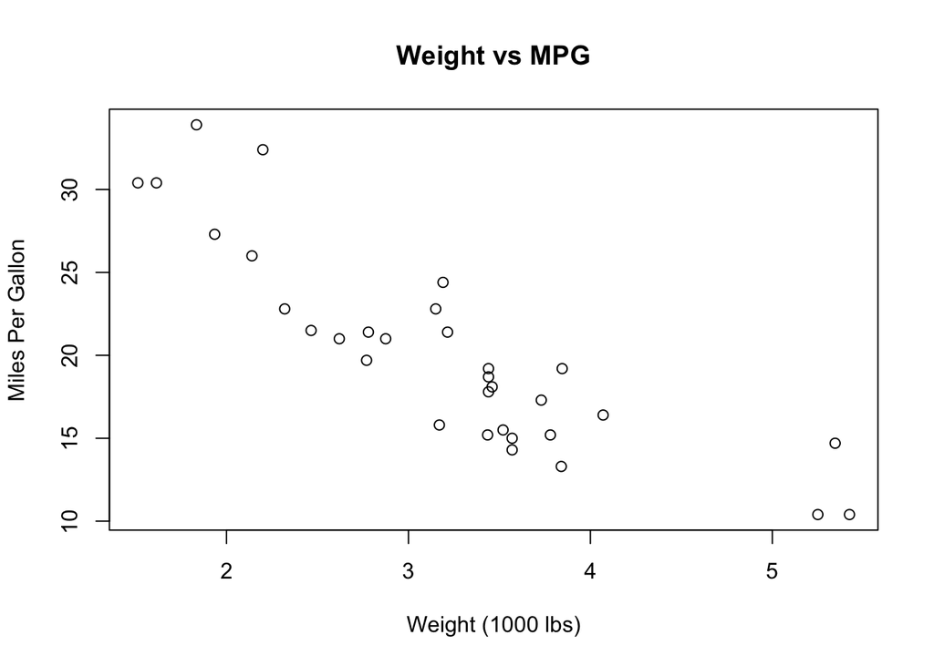

**Hint:** Your chunk header should look like this when you are done: `` ```{r echo=FALSE} ``

### Check

Do you see the plot in the output but **not** the code that created it? Yes

QUESTION: Why might you want to hide code in a final report? ANSWER: To avoid having clunky data.

QUESTION: Can you think of a situation where you would want to **show** your code in a report rather than hide it? Who might be reading that report? ANSWER: If other scientists want to replicate your experiment, they’d likely want to use the same code.

### TASK:

Now apply `echo=FALSE` to the ggplot chunk you created back in Section 3. Knit the document and confirm only the plot appears.

## Step 3: Removing Warnings and Messages

When you load packages or run certain functions, R sometimes prints extra warnings and messages that are not important to the reader. These can make your report look messy. You can suppress them using the chunk options `message=FALSE` and `warning=FALSE`.

### TASK: — Part A: See the messages first

Run the chunk below **without** any chunk options and Knit. Read through the output carefully and write down any extra messages or warnings you notice below.

```r
library(tidyverse)
summary(mtcars)
```

```
##       mpg             cyl             disp             hp
##  Min.   :10.40   Min.   :4.000   Min.   : 71.1   Min.   : 52.0
##  1st Qu.:15.43   1st Qu.:4.000   1st Qu.:120.8   1st Qu.: 96.5
##  Median :19.20   Median :6.000   Median :196.3   Median :123.0
##  Mean   :20.09   Mean   :6.188   Mean   :230.7   Mean   :146.7
##  3rd Qu.:22.80   3rd Qu.:8.000   3rd Qu.:326.0   3rd Qu.:180.0
##  Max.   :33.90   Max.   :8.000   Max.   :472.0   Max.   :335.0
##       drat             wt             qsec             vs
##  Min.   :2.760   Min.   :1.513   Min.   :14.50   Min.   :0.0000
##  1st Qu.:3.080   1st Qu.:2.581   1st Qu.:16.89   1st Qu.:0.0000
##  Median :3.695   Median :3.325   Median :17.71   Median :0.0000
##  Mean   :3.597   Mean   :3.217   Mean   :17.85   Mean   :0.4375
##  3rd Qu.:3.920   3rd Qu.:3.610   3rd Qu.:18.90   3rd Qu.:1.0000
##  Max.   :4.930   Max.   :5.424   Max.   :22.90   Max.   :1.0000
##        am              gear            carb         car_name
##  Min.   :0.0000   Min.   :3.000   Min.   :1.000   Length:32
##  1st Qu.:0.0000   1st Qu.:3.000   1st Qu.:2.000   Class :character
##  Median :0.0000   Median :4.000   Median :2.000   Mode  :character
##  Mean   :0.4062   Mean   :3.688   Mean   :2.812
##  3rd Qu.:1.0000   3rd Qu.:4.000   3rd Qu.:4.000
##  Max.   :1.0000   Max.   :5.000   Max.   :8.000
```

**What messages or warnings did you see?**

### TASK: — Part B: Suppress the messages

Now add `message=FALSE` and `warning=FALSE` to the chunk header above and Knit again.

**Hint:** Your chunk header should look like this when you are done: `` ```{r message=FALSE, warning=FALSE} ``

### Check

Did the extra messages disappear from your rendered output? Yes

QUESTION: What is the difference between `message=FALSE` and `warning=FALSE`? When might you need to use both at the same time? ANSWER: Message is just whatever is in the hashtagged section while warnings are actual warnings with the code. Using both gets rid of both.

QUESTION: Is it always a good idea to suppress warnings? Can you think of a case where seeing a warning might actually be important? ANSWER: A warning might give the answer for why a section of code doesn’t work.

### Why This Matters

Hiding unnecessary messages keeps your report clean and professional, especially when sharing results with someone who does not need to see behind-the-scenes R output. However, always make sure you understand what a warning means before choosing to hide it.

## Step 4: Hiding Code AND Output with `include=FALSE`

In Step 2, you learned that `echo=FALSE` hides the code but still shows the output. Sometimes you may want to run a chunk silently — hiding both the code and the output entirely. This is done with `include=FALSE`.

This is useful for setup steps like loading libraries or defining variables that need to run but do not need to appear in the report.

### TASK:

Run the chunk below as-is and Knit. Note what appears in the output. Then change the chunk option from `echo=FALSE` to `include=FALSE` and Knit again.

**Hint:** Your chunk header should look like this when you are done: `` ```{r include=FALSE} ``

### Check

When using `include=FALSE`, does anything from this chunk appear in the rendered output? No

QUESTION: What is the difference between `echo=FALSE` and `include=FALSE`? ANSWER: The first one only hides the code while the second one hides the code, messages, and warnings.

QUESTION: Give an example of when you would use `include=FALSE` in a real report. ANSWER: To make the data and figures clean to look at.

### TASK:

Now use the `my_summary` object created in the chunk above inside an inline R code sentence below. Even though the chunk is hidden, the object is still available to use. Copy and paste the lines below **outside** of a code chunk and Knit to confirm the values appear.

```
The average miles per gallon across all cars is 20.09 and the most powerful engine produces 335 horsepower.
```

### Check

Did the inline values populate correctly even though the chunk that created them was hidden? Yes

## Step 5: Controlling Figure Size

When creating plots in R Markdown, you can control the size of your figures directly in the chunk header using `fig.width` and `fig.height`. This helps make your report look clean and consistent.

### TASK:

Run the chunk below and Knit to see the default figure size.

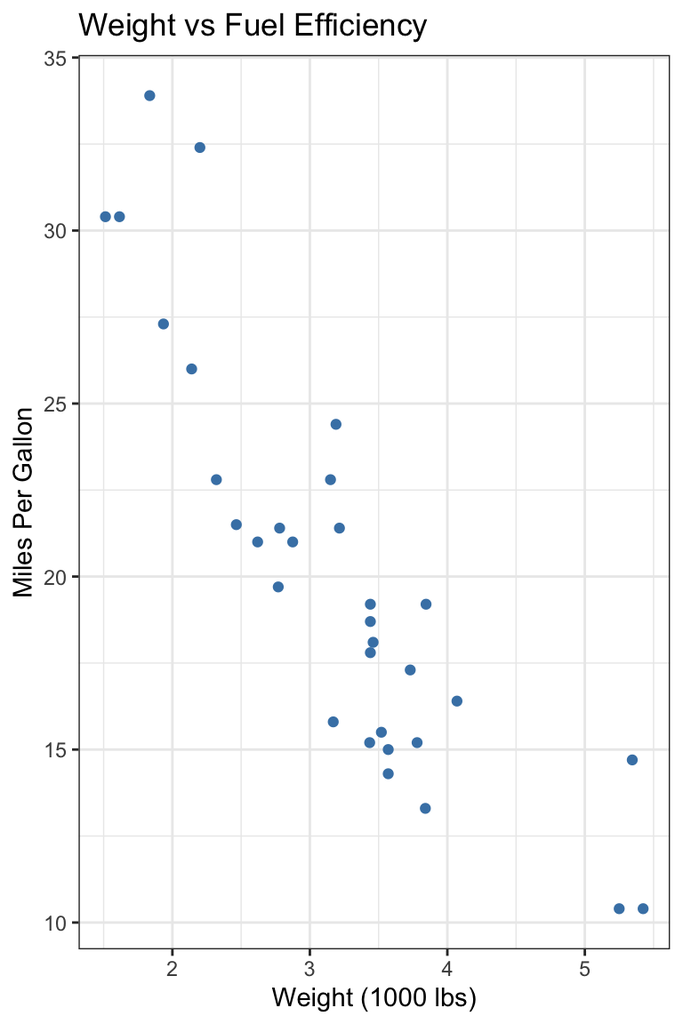

```r
ggplot(mtcars, aes(x = wt, y = mpg)) +
  geom_point(color = "steelblue") +
  labs(title = "Weight vs Fuel Efficiency",
       x = "Weight (1000 lbs)",
       y = "Miles Per Gallon") +
  theme_bw()
```

### TASK:

Now add `fig.width=8` and `fig.height=4` to the chunk header and Knit again.

**Hint:** Your chunk header should look like this when you are done: `` ```{r fig.width=8, fig.height=4} ``

### Check

Did the shape of the plot change in your rendered output?

QUESTION: How did changing `fig.width` and `fig.height` affect the appearance of your plot? ANSWER: It made the width stretch out more.

QUESTION: Why might consistent figure sizing matter in a professional or academic report? ANSWER: It makes it look more refined I guess.

### TASK:

Try setting `fig.width=4` and `fig.height=6` on the same chunk. Knit and observe how the plot changes. Describe what you notice below.

It makes it skinnier and taller.

## Step 6: Adding a Table of Contents

A table of contents makes it easier to navigate your report, especially as it gets longer. You can add one by modifying the YAML header at the very top of your `.Rmd` file.

### TASK:

Make sure the YAML header at the very top of your document looks like this, then Knit:

```yaml
---
title: "Group5_RMarkdown"
author: "Arnav Pandey, Themesha Parker, Michelle Bautista Canuto, Dhanush Devanand"
date: "2026-04-26"
output:
  html_document:
    toc: true
---
```

### Check

Do you now see a table of contents at the top of your rendered HTML document? Yes

QUESTION: How does a table of contents improve the readability of a long report? ANSWER: It makes it easier to navigate to specific sections without scrolling past sections you aren’t interested.

QUESTION: The table of contents is automatically generated from your headings. What does this tell you about the importance of using proper heading levels (`#`, `##`, `###`) throughout your document? ANSWER: It basically makes bullet points with more hashtags being further indented.

## Step 7: Adding Hyperlinks

You can include clickable links in your report to point readers to additional resources. The syntax is `[link text](URL)`.

### TASK:

Add the following clickable link somewhere in your document and Knit:

`[R Markdown documentation](https://rmarkdown.rstudio.com)`

### Check

Does the link appear clickable after knitting? Yes

### TASK:

Now add a second hyperlink of your own. Find a webpage related to something covered in this assignment — for example, the mtcars dataset, ggplot2, or R Markdown chunk options — and add it below using the same syntax. `[Mt cars dataset](http://kaggle.com/datasets/ruiromanini/mtcars)`

QUESTION: When might adding a hyperlink be useful in a data report? ANSWER: To link back to relevent sources.

## Step 8: Writing a Strong Conclusion

Every report should end with a short conclusion that summarizes what was done and what was found.

### TASK:

Write a short paragraph (3–5 sentences) below summarizing what you did in this assignment. Consider:

- What dataset did you use?
- What visualizations or analyses did you create?
- What improvements did you make to the report in Section 5?
- Why is R Markdown useful for communicating data?

Scatterplots, boxplots, and tables were made comparing several variables from the mtcars dataset. Section 5 had a lot of ways of cleaning up and making the data look more professional. This is one of the advantages of R Markdown is letting you use all the functionality of R for the data without forcing people to see every unecessary detail.

### TASK:

Now rewrite at least one sentence from your conclusion so that it includes inline R code. For example, instead of writing “the dataset has 32 rows,” use `32` to generate that number automatically.

Scatterplots, boxplots, and tables were made comparing several variables from the mtcars dataset such as seeing that there are 32 in the dataset.

## Step 9: Final Check and Knit

Before submitting, go through the checklist below to make sure everything is working correctly. In your `.Rmd` file, replace each `[ ]` with `[x]` once you have confirmed that step.

- Inline R code displays correctly in rendered text
- Plots appear in the output without showing code (`echo=FALSE`)
- A chunk runs silently using `include=FALSE`
- No unnecessary warnings or messages appear (`message=FALSE`, `warning=FALSE`)
- Figure sizes have been adjusted using `fig.width` and `fig.height`
- Table of contents is visible at the top of the document
- At least two hyperlinks are present and clickable
- Conclusion paragraph is included with at least one inline R code value

Once all boxes are checked, click **Knit** one final time to generate your completed report.